# Hayman Fire Recovery

Avery Driscoll

2022-02-01

```r
library(tidyverse)
library(tidyr)
library(ggthemes)
library(lubridate)
library(patchwork)

# Now that we have learned how to munge (manipulate) data
# and plot it, we will work on using these skills in new ways

knitr::opts_knit$set(root.dir='..')
```

```r
####Reading in Data and Stacking it####
#Reading in files
files <- list.files('data',full.names=T)

#Read in individual data files
ndmi <- read_csv(files[1]) %>%
  rename(burned=2,unburned=3) %>%
  mutate(data='ndmi')

ndsi <- read_csv(files[2]) %>%
  rename(burned=2,unburned=3) %>%
  mutate(data='ndsi')

ndvi <- read_csv(files[3])%>%
  rename(burned=2,unburned=3) %>%
  mutate(data='ndvi')

# Stack as a tidy dataset
full_long <- rbind(ndvi,ndmi,ndsi) %>%
  gather(key='site',value='value',-DateTime,-data) %>%
  filter(!is.na(value))
```

## Question 1)

What is the correlation between NDVI and NDMI? - here I want you to convert the full_long dataset in to a wide dataset using the function “spread” and then make a plot that shows the correlation as a function of if the site was burned or not (x axis should be ndmi) You should exclude winter months and focus on summer months

```r
#Exclude months in October through May, use pivot_wider to give each variable its own column
sub_wide <- full_long %>%
  filter(month(DateTime) %in% c(06, 07, 08, 09)) %>%
  pivot_wider(names_from = data, values_from = value)

#Check relationship between NDMI and NDVI for all sites;
summary.lm(lm(ndmi~ndvi, sub_wide))
```

```
##
## Call:
## lm(formula = ndmi ~ ndvi, data = sub_wide)
##
## Residuals:
##      Min       1Q   Median       3Q      Max
## -0.17986 -0.04198 -0.01339  0.02153  0.92503
##
## Coefficients:
##              Estimate Std. Error t value Pr(>|t|)
## (Intercept) -0.273001   0.007262  -37.59   <2e-16 ***
## ndvi         0.636478   0.018715   34.01   <2e-16 ***
## ---
## Signif. codes:  0 '***' 0.001 '**' 0.01 '*' 0.05 '.' 0.1 ' ' 1
##
## Residual standard error: 0.0747 on 1259 degrees of freedom
##   (12 observations deleted due to missingness)
## Multiple R-squared:  0.4788, Adjusted R-squared:  0.4784
## F-statistic:  1157 on 1 and 1259 DF,  p-value: < 2.2e-16
```

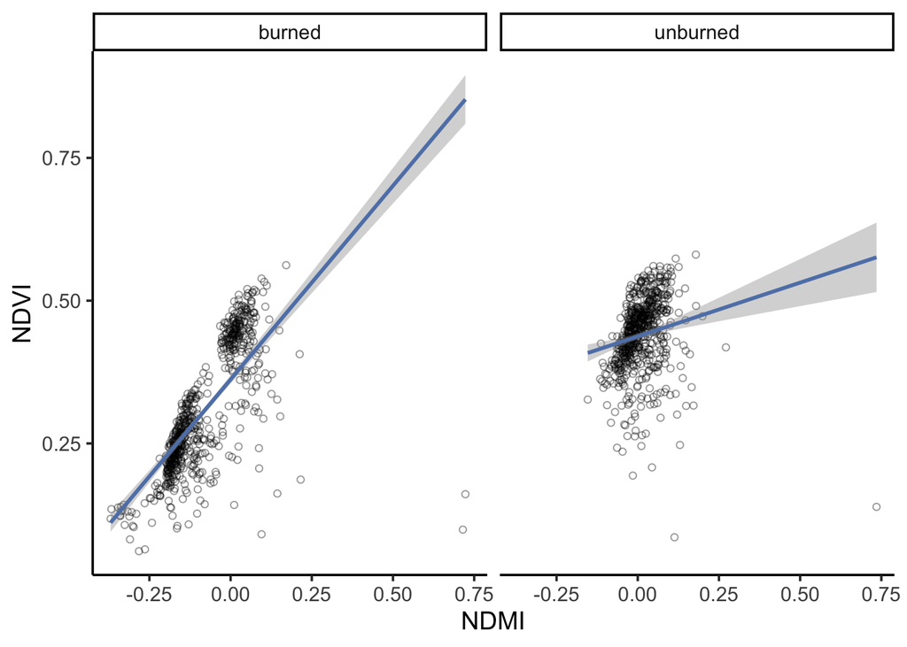

```r
#Make figure with NDMI vs. NDVI with separate panels for burned/unburned
ggplot(sub_wide, aes(x = ndmi, y = ndvi)) +
    geom_point(alpha = 0.4, shape = 1) +
    geom_smooth(method = lm, color = "#6082B6") +
    theme_classic(base_size = 14) + facet_wrap(~site) +
    xlab("NDMI") + ylab("NDVI")
```

## Question 2

2. What is the correlation between average NDSI (normalized snow index) for January - April and average NDVI for June-August? In other words, does the previous year’s snow cover influence vegetation growth for the following summer?

Across all the data (pre-burn and post-burn and both sites), there is no relationship between winter NDSI and summer NDVI (p = 0.78).

```r
#Filter Jan-April NDSI and remove NAs, group by year and calculate seasonal means
ndsi_sum <- full_long %>%
  filter(data == "ndsi", month(DateTime) %in% c(01, 02, 03, 04)) %>%
  group_by(year(DateTime)) %>%
  summarize(mean_ndsi = mean(value))

#Filter June-August NDVI and remove NAs,
ndvi_sum <- full_long %>%
  filter(data == "ndvi", month(DateTime) %in% c(06, 07, 08)) %>%
  group_by(year(DateTime)) %>%
  summarize(mean_ndvi = mean(value))

#Rename columns
colnames(ndvi_sum) <- c("year", "ndvi")
colnames(ndsi_sum) <- c("year", "ndsi")

#Merge data by year
df_sum <- merge(ndvi_sum, ndsi_sum, by = "year")

#Check for relationship between ndvi and ndsi
summary.lm(lm(ndvi~ndsi, df_sum))
```

```
##
## Call:
## lm(formula = ndvi ~ ndsi, data = df_sum)
##
## Residuals:
##      Min       1Q   Median       3Q      Max
## -0.14718 -0.05975  0.01398  0.05858  0.10630
##
## Coefficients:
##             Estimate Std. Error t value Pr(>|t|)
## (Intercept)  0.38471    0.01223  31.457   <2e-16 ***
## ndsi         0.01770    0.06339   0.279    0.782
## ---
## Signif. codes:  0 '***' 0.001 '**' 0.01 '*' 0.05 '.' 0.1 ' ' 1
##
## Residual standard error: 0.07173 on 34 degrees of freedom
## Multiple R-squared:  0.002287,   Adjusted R-squared:  -0.02706
## F-statistic: 0.07795 on 1 and 34 DF,  p-value: 0.7818
```

## Q3

How is the snow effect from question 2 different between pre- and post-burn and burned and unburned?

There was no significant relationship between NDVI and NDSI at the burned site across the entire study period (p = 0.62), before the fire (p = 0.73), or after the fire (p = 0.38). There was also no relationship between the two variables at the unburned site across the entire study period (p = 0.86), before the fire (p = 0.59), or after the fire (p = 0.70).

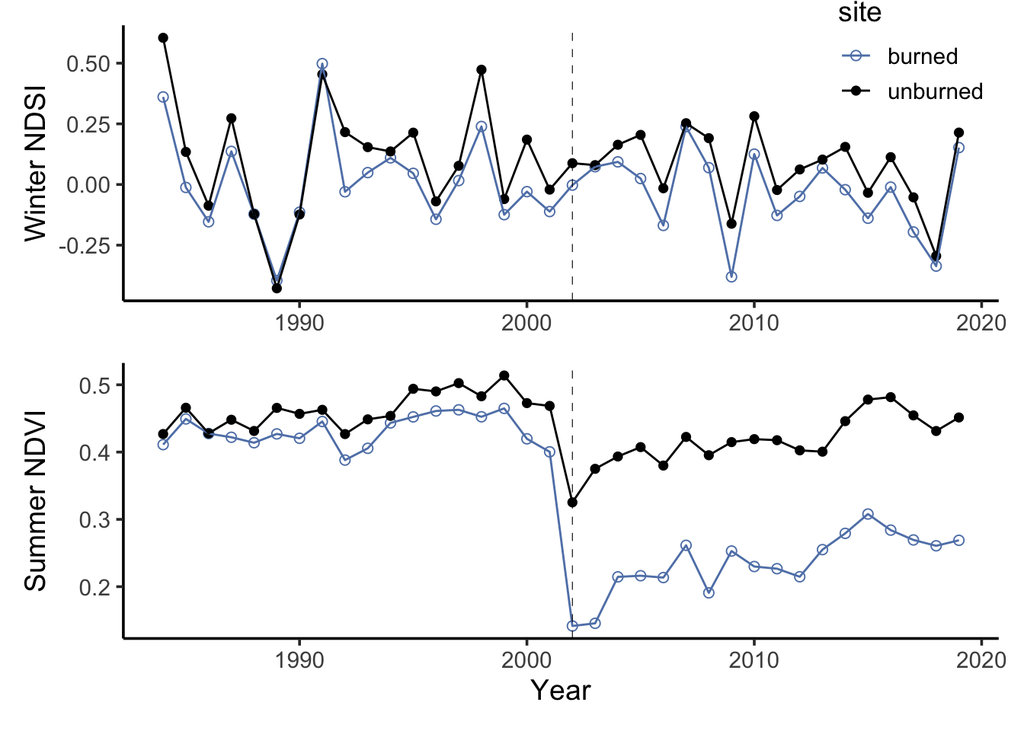

```r
#Modify code from Q2 to also group by site for both NDSI and NDVI
ndsi_sum <- full_long %>%
  filter(data == "ndsi", month(DateTime) %in% c(01, 02, 03, 04)) %>%
  group_by(year(DateTime), site) %>%
  summarize(mean_ndsi = mean(value))

ndvi_sum <- full_long %>%
  filter(data == "ndvi", month(DateTime) %in% c(06, 07, 08)) %>%
  group_by(year(DateTime), site) %>%
  summarize(mean_ndvi = mean(value))

#Rename columns
colnames(ndvi_sum) <- c("year", "site", "ndvi")
colnames(ndsi_sum) <- c("year", "site", "ndsi")

#Merge data by year and site
df_sum <- merge(ndvi_sum, ndsi_sum, by = c("year", "site"))

#visualize timeseries across all data
a <- ggplot(df_sum, aes(x = year, y = ndsi)) +
  geom_point(size = 2, aes(color = site, shape = site)) +
  geom_line(aes(color = site)) + theme_classic(base_size = 14) +
  theme(legend.position = c(0.9, 0.9)) +
  scale_color_manual(values = c("#6082B6", "black")) +
  scale_shape_manual(values = c(1, 16)) +
  ylab("Winter NDSI") + xlab(NULL) +
  geom_vline(xintercept = 2002, linetype = "dashed", size = 0.2)

b <- ggplot(df_sum, aes(x = year, y = ndvi)) +
  geom_point(size = 2, aes(color = site, shape = site)) +
  geom_line(aes(color = site)) + theme_classic(base_size = 14) +
  theme(legend.position = "none") +
  scale_color_manual(values = c("#6082B6", "black")) +
  scale_shape_manual(values = c(1, 16)) +
  ylab("Summer NDVI") + xlab("Year") +
  geom_vline(xintercept = 2002, linetype = "dashed", size = 0.2)

a/b
```

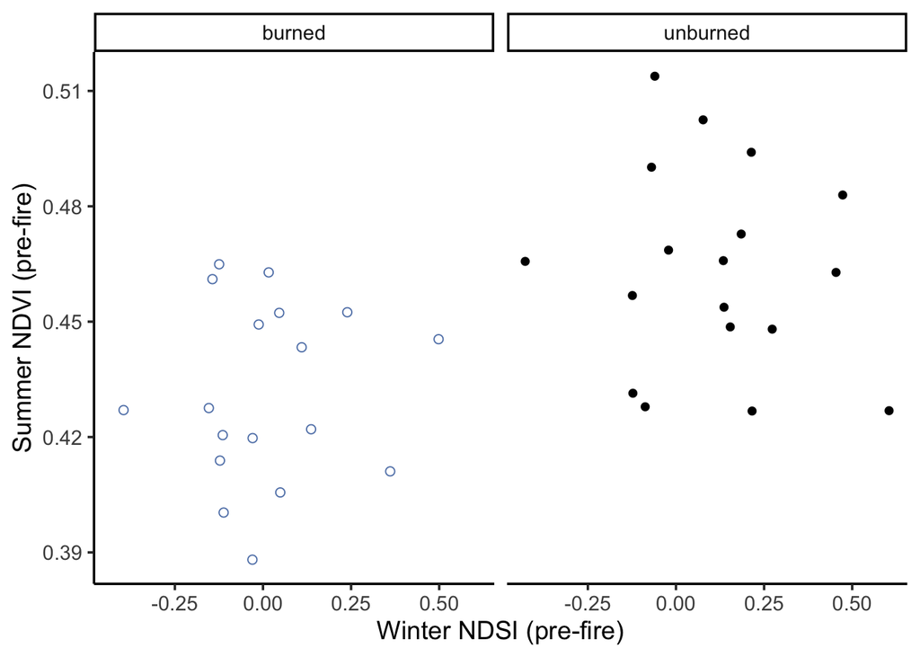

```r
#Plot NDVI vs. NDMI correlations pre-fire and post fire for burned and unburned sites
ggplot(subset(df_sum, year < 2002), aes(x = ndsi, y = ndvi, color = site, shape = site)) +
  geom_point(size = 2) + theme_classic(base_size = 14) +
  theme(legend.position = "none") +
  scale_color_manual(values = c("#6082B6", "black")) +
  scale_shape_manual(values = c(1, 16)) +
  ylab("Summer NDVI (pre-fire)") + xlab("Winter NDSI (pre-fire)") + facet_wrap(~site)
```

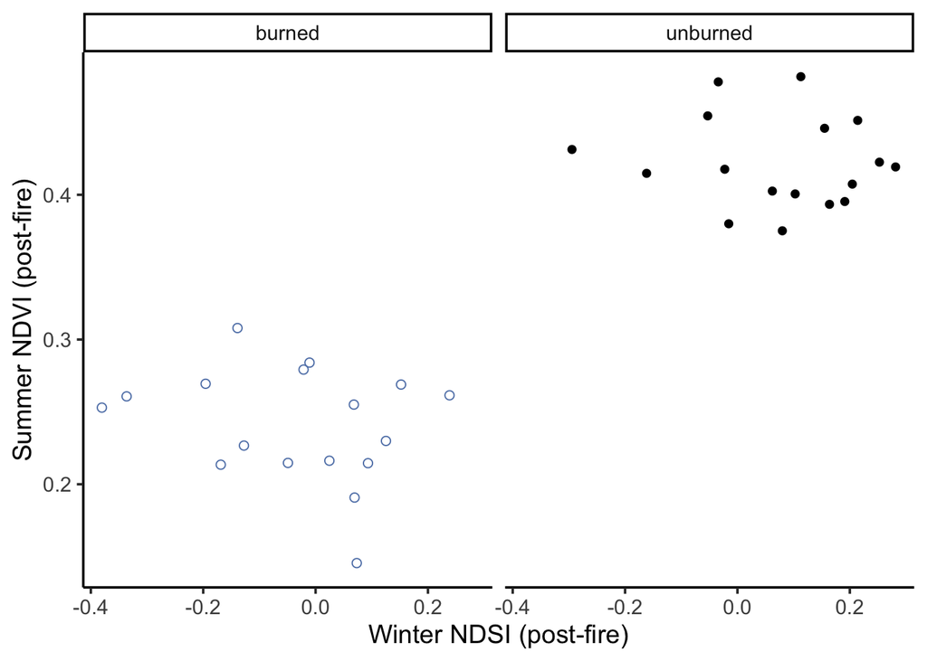

```r
ggplot(subset(df_sum, year > 2002), aes(x = ndsi, y = ndvi, color = site, shape = site)) +
  geom_point(size = 2) + theme_classic(base_size = 14) +
  theme(legend.position = "none") +
  scale_color_manual(values = c("#6082B6", "black")) +
  scale_shape_manual(values = c(1, 16)) +
  ylab("Summer NDVI (post-fire)") + xlab("Winter NDSI (post-fire)") + facet_wrap(~site)
```

```r
#check for relationship between NDVI and NDSI at burned site and at unburned site across all years
summary.lm(lm(ndvi~ndsi, data = subset(df_sum, site == "burned")))
```

```
##
## Call:
## lm(formula = ndvi ~ ndsi, data = subset(df_sum, site == "burned"))
##
## Residuals:
##      Min       1Q   Median       3Q      Max
## -0.19213 -0.08821  0.01828  0.09444  0.13712
##
## Coefficients:
##             Estimate Std. Error t value Pr(>|t|)
## (Intercept)  0.33385    0.01783   18.73   <2e-16 ***
## ndsi         0.04857    0.09713    0.50     0.62
## ---
## Signif. codes:  0 '***' 0.001 '**' 0.01 '*' 0.05 '.' 0.1 ' ' 1
##
## Residual standard error: 0.1068 on 34 degrees of freedom
## Multiple R-squared:  0.0073, Adjusted R-squared:  -0.0219
## F-statistic:  0.25 on 1 and 34 DF,  p-value: 0.6203
```

```r
summary.lm(lm(ndvi~ndsi, data = subset(df_sum, site == "unburned")))
```

```
##
## Call:
## lm(formula = ndvi ~ ndsi, data = subset(df_sum, site == "unburned"))
##
## Residuals:
##       Min        1Q    Median        3Q       Max
## -0.114631 -0.023829  0.007764  0.026673  0.073039
##
## Coefficients:
##              Estimate Std. Error t value Pr(>|t|)
## (Intercept)  0.440439   0.007456  59.070   <2e-16 ***
## ndsi        -0.005889   0.033632  -0.175    0.862
## ---
## Signif. codes:  0 '***' 0.001 '**' 0.01 '*' 0.05 '.' 0.1 ' ' 1
##
## Residual standard error: 0.04064 on 34 degrees of freedom
## Multiple R-squared:  0.0009009,  Adjusted R-squared:  -0.02848
## F-statistic: 0.03066 on 1 and 34 DF,  p-value: 0.862
```

```r
#check for pre-fire (2002) relationship between NDVI and NDSI at each site
summary.lm(lm(ndvi~ndsi, data = subset(df_sum, site == "unburned" & year < 2002)))
```

```
##
## Call:
## lm(formula = ndvi ~ ndsi, data = subset(df_sum, site == "unburned" &
##     year < 2002))
##
## Residuals:
##      Min       1Q   Median       3Q      Max
## -0.03824 -0.01379 -0.00118  0.02086  0.04811
##
## Coefficients:
##              Estimate Std. Error t value Pr(>|t|)
## (Intercept)  0.464875   0.006974  66.656   <2e-16 ***
## ndsi        -0.014147   0.026026  -0.544    0.594
## ---
## Signif. codes:  0 '***' 0.001 '**' 0.01 '*' 0.05 '.' 0.1 ' ' 1
##
## Residual standard error: 0.0269 on 16 degrees of freedom
## Multiple R-squared:  0.01813,    Adjusted R-squared:  -0.04324
## F-statistic: 0.2955 on 1 and 16 DF,  p-value: 0.5942
```

```r
summary.lm(lm(ndvi~ndsi, data = subset(df_sum, site == "burned" & year < 2002)))
```

```
##
## Call:
## lm(formula = ndvi ~ ndsi, data = subset(df_sum, site == "burned" &
##     year < 2002))
##
## Residuals:
##       Min        1Q    Median        3Q       Max
## -0.043002 -0.015099 -0.001454  0.018534  0.034733
##
## Coefficients:
##             Estimate Std. Error t value Pr(>|t|)
## (Intercept) 0.431402   0.005619  76.773   <2e-16 ***
## ndsi        0.009744   0.027910   0.349    0.732
## ---
## Signif. codes:  0 '***' 0.001 '**' 0.01 '*' 0.05 '.' 0.1 ' ' 1
##
## Residual standard error: 0.0238 on 16 degrees of freedom
## Multiple R-squared:  0.00756,    Adjusted R-squared:  -0.05447
## F-statistic: 0.1219 on 1 and 16 DF,  p-value: 0.7316
```

```r
#check for post-fire relationship between NDVI and NDSI at each site
summary.lm(lm(ndvi~ndsi, data = subset(df_sum, site == "unburned" & year > 2001)))
```

```
##
## Call:
## lm(formula = ndvi ~ ndsi, data = subset(df_sum, site == "unburned" &
##     year > 2001))
##
## Residuals:
##      Min       1Q   Median       3Q      Max
## -0.09085 -0.01745 -0.00354  0.02625  0.06611
##
## Coefficients:
##             Estimate Std. Error t value Pr(>|t|)
## (Intercept)  0.41833    0.01034  40.469   <2e-16 ***
## ndsi        -0.02498    0.06351  -0.393    0.699
## ---
## Signif. codes:  0 '***' 0.001 '**' 0.01 '*' 0.05 '.' 0.1 ' ' 1
##
## Residual standard error: 0.0391 on 16 degrees of freedom
## Multiple R-squared:  0.00958,    Adjusted R-squared:  -0.05232
## F-statistic: 0.1548 on 1 and 16 DF,  p-value: 0.6992
```

```r
summary.lm(lm(ndvi~ndsi, data = subset(df_sum, site == "burned" & year > 2001)))
```

```
##
## Call:
## lm(formula = ndvi ~ ndsi, data = subset(df_sum, site == "burned" &
##     year > 2001))
##
## Residuals:
##       Min        1Q    Median        3Q       Max
## -0.091802 -0.019950  0.000602  0.038266  0.066423
##
## Coefficients:
##             Estimate Std. Error t value Pr(>|t|)
## (Intercept)  0.23324    0.01090  21.393 3.38e-13 ***
## ndsi        -0.05950    0.06656  -0.894    0.385
## ---
## Signif. codes:  0 '***' 0.001 '**' 0.01 '*' 0.05 '.' 0.1 ' ' 1
##
## Residual standard error: 0.04533 on 16 degrees of freedom
## Multiple R-squared:  0.04757,    Adjusted R-squared:  -0.01196
## F-statistic: 0.7991 on 1 and 16 DF,  p-value: 0.3846
```

## Question 4

What month is the greenest month on average?

At the unburned site, September has the highest average NDVI over this study period. At the burned site, August has the highest average NDVI over the study period

```r
#Aggregate ndvi by month (keep sites separate)
ndvi_sum <- full_long %>%
  filter(data == "ndvi") %>%
  group_by(month(DateTime), site) %>%
  summarize(mean_ndvi = mean(value)) %>%
  pivot_wider(names_from = site, values_from = mean_ndvi)

#gives the month corresponding to the maximum value for the burned and unburned sites
ndvi_sum[which.max(ndvi_sum$burned), 1]
```

```
## # A tibble: 1 × 1
## # Groups:   month(DateTime) [1]
##   `month(DateTime)`
##               <dbl>
## 1                 8
```

```r
ndvi_sum[which.max(ndvi_sum$unburned), 1]
```

```
## # A tibble: 1 × 1
## # Groups:   month(DateTime) [1]
##   `month(DateTime)`
##               <dbl>
## 1                 9
```

## Question 5)

What month is the snowiest on average?

At the unburned site, February has the highest average NDSI over the study period. At the burned site, January has the highest NDSI over the study period.

```r
#Aggregate ndsi by month (sites separate)
ndsi_sum <- full_long %>%
  filter(data == "ndsi") %>%
  group_by(month(DateTime), site) %>%
  summarize(mean_ndsi = mean(value) )%>%
  pivot_wider(names_from = site, values_from = mean_ndsi)

#gives the month corresponding to the maximum value for the burned and unburned sites
ndsi_sum[which.max(ndsi_sum$burned), 1]
```

```
## # A tibble: 1 × 1
## # Groups:   month(DateTime) [1]
##   `month(DateTime)`
##               <dbl>
## 1                 1
```

```r
ndsi_sum[which.max(ndsi_sum$unburned), 1]
```

```
## # A tibble: 1 × 1
## # Groups:   month(DateTime) [1]
##   `month(DateTime)`
##               <dbl>
## 1                 2
```

## Bonus Question: Redo all problems with `spread` and `gather` using modern tidyverse syntax.

## Bonus Question: Use Climage Engine to pull the same data for the assignment, but updated with 2020/2021 data.